# experiments_on_dataset

Eric Bridgeford

October 2, 2016

## Basis for Model

The basis for the experimental model is Expectation-Maximization of the Gaussian Mixture Model (GMM). Here, we will detail several experiments that show that our model works through data-driven simulations, demonstrate the adjustments to GMM that we make, show that they work for simulation data, and finally investigate how the experimental data fits the model.

## Basic Gaussian Mixture Model

The basic Gaussian Mixture Model hinges on Expectation-Maximization, a process for finding a locally maximizing fit for mixed distributions of the exponential family. GMM has 2 steps, the expectation (or responsibility) step, and the maximization step, and repeats until our log likelihood converges.

## Experimental Model (time-variant GMM, tGMM)

For our experiment, we have task fMRI data in which test subjects have a task presented before them at known points in time. We theorize that the latent signals driving thinking patterns can be represented by a gaussian mixture, and that we can adjust EM to predict the covariance matrices of each experimental task condition. We define our density function of an observed $x$ of some latent signal $z$:

\begin{equation} p(x_i) = \sum_{c} \pi_{ic} N(x_i | \mu_c, \Sigma_c) \end{equation}

Using our predicted covariance matrices for each experimental task condition, we can then use the Wilcoxon signed-rank test to find rois that show differential activity based on task condition.

### tGMM Framework

#### E Step

Like traditional GMM, our expectation step consists of computing the responsibilities of each potential cluster on our individual data points. \begin{equation} r_{ic} = \frac{\pi_{ic}N(x | \mu_c, \Sigma_c)}{\sum_{c'}\pi_{ic'}N(x | \mu_{c'}, \Sigma_{c'})} \end{equation}

where $r_ic$ represents the given responsibility of a cluster $c$ on time point $i$. This is a relatively intuitive process, as we are essentially considering the probability that a given data point is a member of a cluster and normalizing by the probability that it is in any of the clusters.

#### M Step

Again, much of our process here will look very similar to traditional GMM. As we have information about how the task conditions evolve over time, however, we can skip prediction of the $\pi$ vector entirely. To define some $\rho$ vector, we can convolve a spike train $f$ of condition onsets with a response function that gives the expected proportion of signal at each successive timestep after an impulse, such that:

\begin{equation} \rho_{c} = f_c(i)*h(i) \end{equation}

For each condition $c$, and where $\rho_c$ is defined for each timestep $i$. We normalize our $\rho$ vector to sum to 1 at each time point, calling the normalized vector $\pi$:

\begin{equation} \pi_{ic} = \frac{\rho_{ic}}{\sum_c' \rho_{ic'}} \end{equation}

and now our model is simply a time-variant adaptation of GMM.

The cumulative responsibility of a given cluster $c$

\begin{equation} m_c = \sum_i r_{ic} \end{equation} For updated means. The logic behind the mean maximization is that we consider how much a particular cluster “explains” our $i$th data point, so $\mu$ is more strongly impacted by data points that it explains more effectively. \begin{equation} \hat{\mu_c} = \frac{1}{m_c} \sum_i r_{ic}x_i \end{equation} For updating the covariances. The logi here is again the same; if a point is explained well by a particular distribution, its covariance is more strongly considered than if it isn’t explained by that distribution. \begin{equation} \hat{\Sigma_c} = \frac{1}{m_c} \sum_i r_{ic}(x_i - \hat{\mu_c})^T(x_i - \hat{\mu_c}) \end{equation}

We repeat the expectation and maximization steps until we reach convergence of the likelihood (and consequently the log likelihood) of our predicted clusters matching our data.

\begin{equation} log(p(X)) = \sum_i log[\sum_c \pi_{ic} N(x_i | \mu_c, \Sigma_c)] \end{equation}

### wwCon framework

This is not a machine learning algorithm, but rather, a weighted version of traditional measures of timeseries data.

#### Weighted Mean

\begin{equation} \mu = \frac{\sum_{i=1}^N w_i m_i}{\sum_{i=1}^N w_i} \end{equation}

or our overall mean for a particular condition is just a weighted combination of the means at each timepoint, where our weight vector $w$ just indicates the weight a particular condition is thought to be present at a given time point.

#### Weighted Covariance

For the covariance, we use the unbiased sample covariance:

\begin{equation} \Sigma = \frac{1}{\sum_{i=1}^N w_i - 1}{\sum_{i=1}^N w_i(x_i - \mu)^T(x_i - \mu)} \end{equation}

### Pseudo Code

A link of the pseudo code can be found here.[tGMM](https://github.com/NeuroDataDesign/fngs/blob/gh-pages/reveal/pdfs/tGMM_algo.pdf)

#### Wilcoxon Signed-Rank Test

Here, the data is clearly paired, as we would expect a relationship between correlation values taken at the within-subject level, and the within-scan level. We do not want to impose parametricity for the covariance values being analyzed, so we proceed with the non-parametric wilcoxon signed-rank test.

## Simulated Results

### Super-Simple Example

In this super simple example, we consider one ROI with perfectly separated conditions. We sample for each condition from a normal distribution with mean/cov as shown below.

```r
  require('MASS')
```

```r
  source('tGMM.R')
  source('./wwCon.R')
  source('../drivers/plot_one_mtx.R')

  nt <- 100
  ncond <- 2
  nroi <- 1
  mu <- array(0, dim=c(nroi, ncond))
  mu[,1] <- 3
  mu[,2] <- -3
  sigma <- array(1, dim=c(nroi, nroi, ncond))
  pi_v <- array(0, dim=c(nt, ncond))
  pi_v[1:50, 1] <- 1
  pi_v[51:100,2] <- 1

  latent_signal <- array(0, dim=c(ncond, nt, nroi))
  for (i in 1:ncond) {
    library(randomts)
    latent_signal[i,,] <- mvrnorm(n = nt, mu = mu[,i], Sigma <- sigma[,,i])
  }

   observed_signal <- array(sapply(1:dim(latent_signal)[2], function(t) {
    sum(pi_v[t,]*latent_signal[,t,])
  }), dim=c(nt, nroi))

   #test <- wwCon(observed_signal, mu, sigma, pi_v)
   test <- wwCon(observed_signal, pi_v)
   trusig <- c(var(observed_signal[1:50,1]), var(observed_signal[51:100,1]))
   trumean <- c(mean(observed_signal[1:50,1]), mean(observed_signal[51:100,1]))
   print(paste("True Means>>", max(trumean), min(trumean)))
```

```
## [1] "True Means>> 3.14610066910751 -2.90003946593645"
```

```r
   print(paste("Predicted Means>>", max(test$means), min(test$means)))
```

```
## [1] "Predicted Means>> 3.14610066910751 -2.90003946593645"
```

```r
   print(paste("True Cov>>", max(trusig), min(trusig)))
```

```
## [1] "True Cov>> 1.60535630617849 1.05793566395632"
```

```r
   print(paste("Predicted Cov>>", max(test$covs), min(test$covs)))
```

```
## [1] "Predicted Cov>> 1.57324918005492 1.03677695067719"
```

## More Complex Example

In this more complex example, we consider a 4 ROI dataset. This dataset has 3 conditions, and the condition periods overlap slightly. Additionally, as we can see, the response function is not a simple rectangular window (it has a bell shape, more similar to that of the hemodynamic response).

```r
  nroi <- 4
  ncond <- 3
  nt <- 300
  window <- array(c(0, 1, 3, 4, 3, 1, 0))

  # predict a diagonal matrix for simple case
  predict_mean <- array(0, dim=c(nroi, ncond))
  predict_cov <- array(sapply(1:ncond, function(x) diag(nroi), simplify='array'), dim=c(nroi, nroi, ncond))
  test_dat <- get_sample_data(nt, ncond, nroi, window, offset=5, overlap=3)
```

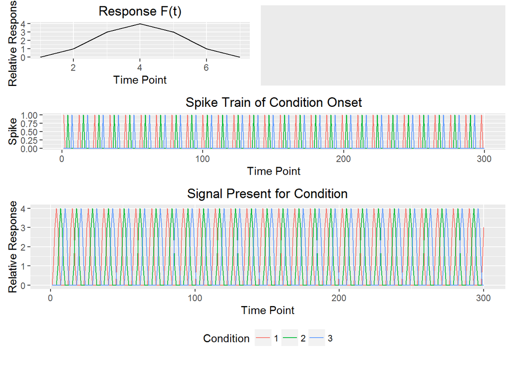

```r
  #test <- wwCon(test_dat$x[2:nt,,drop=FALSE], array(0, dim=c(nroi, ncond)), predict_cov,
  #             test_dat$pi_v[2:nt,,drop=FALSE])
  test <- wwCon(test_dat$x[2:nt,,drop=FALSE], test_dat$pi_v[2:nt,,drop=FALSE])
  print(t(test_dat$mean))
```

```
##           [,1]       [,2]       [,3]
## [1,] 0.7846206 -1.1927758  0.5221490
## [2,] 0.6454519  0.7087784 -1.0289643
## [3,] 1.2466333  0.1756708 -0.5817899
## [4,] 0.7616794 -0.4363682 -0.8075832
```

```r
  print(test_dat$cov)
```

```
## , , 1
##
##            [,1]        [,2]        [,3]        [,4]
## [1,]  1.1154191 -0.61670835  0.61835961 -0.02736300
## [2,] -0.6167083  4.16950098 -2.28291213 -0.06293407
## [3,]  0.6183596 -2.28291213  2.80736917 -0.07044554
## [4,] -0.0273630 -0.06293407 -0.07044554  1.06184764
##
## , , 2
##
##             [,1]        [,2]       [,3]        [,4]
## [1,]  1.00047231  0.26260451 -0.5427852 -0.07823912
## [2,]  0.26260451  1.46904429 -1.1425836  0.01494746
## [3,] -0.54278517 -1.14258360  3.6679519  0.13407725
## [4,] -0.07823912  0.01494746  0.1340772  1.12812417
##
## , , 3
##
##             [,1]       [,2]        [,3]       [,4]
## [1,]  1.34311862  0.5717030 -0.05168843 0.12783873
## [2,]  0.57170299  2.1731664 -0.19785449 0.29067038
## [3,] -0.05168843 -0.1978545  0.99704063 0.01166169
## [4,]  0.12783873  0.2906704  0.01166169 1.00171065
```

```r
  print(test$means)
```

```
##           [,1]       [,2]       [,3]
## [1,] 0.5697204 -0.7610454  0.2655449
## [2,] 0.6144379  0.6485695 -0.9251522
## [3,] 1.1554986  0.3653795 -0.5175271
## [4,] 0.6827595 -0.1460211 -0.7381217
```

```r
  print(test$covs)
```

```
## , , 1
##
##             [,1]        [,2]        [,3]        [,4]
## [1,]  1.06699160 -0.58852134  0.62517926 -0.03506027
## [2,] -0.58852134  4.02488956 -2.22756604 -0.06910562
## [3,]  0.62517926 -2.22756604  2.57604050 -0.09040142
## [4,] -0.03506027 -0.06910562 -0.09040142  0.90496943
##
## , , 2
##
##             [,1]        [,2]        [,3]       [,4]
## [1,]  0.84827908  0.07296868 -0.47323801 0.06722581
## [2,]  0.07296868  1.33460129 -0.53146577 0.20217004
## [3,] -0.47323801 -0.53146577  2.22930460 0.03079808
## [4,]  0.06722581  0.20217004  0.03079808 0.83801231
##
## , , 3
##
##            [,1]       [,2]          [,3]         [,4]
## [1,]  1.3822140  0.5799125 -0.1132182728 0.1157296930
## [2,]  0.5799125  2.5563365 -0.2184133605 0.1619139588
## [3,] -0.1132183 -0.2184134  1.1150456161 0.0002748023
## [4,]  0.1157297  0.1619140  0.0002748023 0.8980028429
```

```r
  # llp <- ggplot(data = melt(test$ll), aes(x=1:length(test$ll), y=value)) +
  #   geom_line(size=1.5, color='green') +
  #   xlab('Number of Iterations') +
  #   ylab('Log Likelihood')
  # multiplot(plotlist=list(llp), layout=matrix(c(1), nrow=1, byrow=TRUE))
```

```r
  mean_true <- list()
  mean_est <- list()
  cov_true <- list()
  cov_est <- list()

  for (i in 1:ncond) {
    testlims <- c(max(test_dat$mean), min(test_dat$mean))
    mean_true[[i]] <- plot_one_vec(array(test_dat$mean[i,]), lims = testlims, scale="mean", textsize=10) + ggtitle(paste('True Mean for Condition', i))
    mean_est[[i]] <- plot_one_vec(array(test$means[,i]), lims = testlims, scale="mean", textsize=10) + ggtitle(paste('Maximized Mean for Condition', i))
    testlims <- c(max(test_dat$cov), min(test_dat$cov))
    cov_true[[i]] <- plot_one_mtx(test_dat$cov[,,i], lims = testlims, scale="cov", textsize=10) + ggtitle(paste('Truth Cov for Condition', i))
    cov_est[[i]] <- plot_one_mtx(test$covs[,,i], lims = testlims, scale="cov", textsize=10) + ggtitle(paste('Maximized for Condition', i))
  }

  multiplot(plotlist=mean_true, layout=matrix(c(1,2,3), nrow=1, byrow=TRUE))
  multiplot(plotlist=mean_est, layout=matrix(c(1,2,3), nrow=1, byrow=TRUE))
  multiplot(plotlist=cov_true, layout=matrix(c(1,2,3), nrow=1, byrow=TRUE))
  multiplot(plotlist=cov_est, layout=matrix(c(1,2,3), nrow=1, byrow=TRUE))
```

[output not shown]

## Real Data Exploratory Analysis

To begin, we demonstrate some formal proofs-of-concept of our idea on the real data. First, we must demonstrate that time periods we denote as particular conditions actually show differening covariance and means. Note that we skip loading and sourcing operations for simplicity, and pick up our function assuming that we have loaded our timeseries successfully:

### wwCon

We get our condition onsets and store our $\pi$ vector:

```r
  ## Condition Onset/Correlation ---------------------------------------------------
  cond_key <- c("Relational", "Locational", "Incorrect")
  onsets <- get_trial_onsets(infopath, ts, subs, runs, onset_cat=c(1,1,2,2,1,1,2,2,3), cond_key=cond_key)
  onset_times <- onsets$times
  conditions <- onsets$conditions

  # Rectangular window
  #fx <- c(0,1,1,1,1,0)
  # Asymmetric Window
  fx <- array(rev(c(0, .1, .2, .3, .2, .1, 0)))

  pi_vecs <- sapply(onset_times, function(sub) {
    abs(apply(sub, 2, function(x) as.array(convolve(x, fx, type='open')[1:length(x)])))
  }, USE.NAMES=TRUE, simplify=FALSE)
  pi_vecs <- sapply(pi_vecs, function(sub) {
     sub[,3] <- rep(.1, length=dim(sub)[1])
     return(abs(sub))
  }, USE.NAMES=TRUE, simplify=FALSE)
  cond_key <- c("Relational", "Locational", "Overall")
```

```r
  ## Wilcoxon Tests ----------------------------------------------------------

  wwcon_results <- sapply(names(ts), function(sub) wwCon(ts[[sub]], pi_vecs[[sub]]),
                                USE.NAMES=TRUE, simplify=FALSE)
  cov_wwcon <- list()
  mean_wwcon <- list()

  for (i in 1:length(cond_key)) {
    cov_wwcon[[cond_key[i]]] <- list()
    mean_wwcon[[cond_key[i]]] <- list()

    for (id in names(wwcon_results)) {
      cov_wwcon[[cond_key[i]]][[id]] <- wwcon_results[[id]]$covs[,,i]
      mean_wwcon[[cond_key[i]]][[id]] <- wwcon_results[[id]]$means[,i]
    }
  }

  wwcon_mean_wilcox <- wilcox_test_mean(mean_wwcon, subs, runs)

  wwcon_cov_wilcox <- wilcox_test_cov(cov_wwcon, subs, runs)

  wwcon_wilcox_plot_cov <- plot_cov_wilcox(wwcon_cov_wilcox, textsize=10)
  wwcon_wilcox_plot_mean <- plot_mean_wilcox(wwcon_mean_wilcox, atlas, textsize=10)
```

We can visualize the wilcoxon test results, where a low p-value indicates that a particular edge shows a difference in covariance for a particular condition. Note that we use the signed rank test, and not the related rank-sum test, since our data is paired (ie, we would expect some sort of dependence of our covariance values in the overall period compared to a particular condition since our overall period includes all of the observations of our particular condition periods).

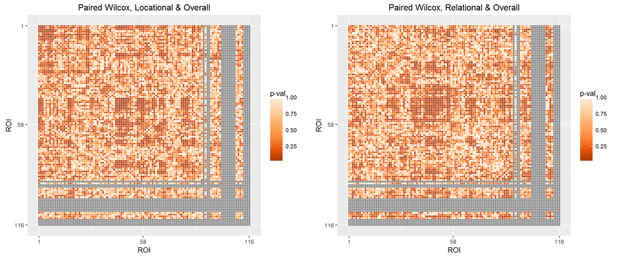

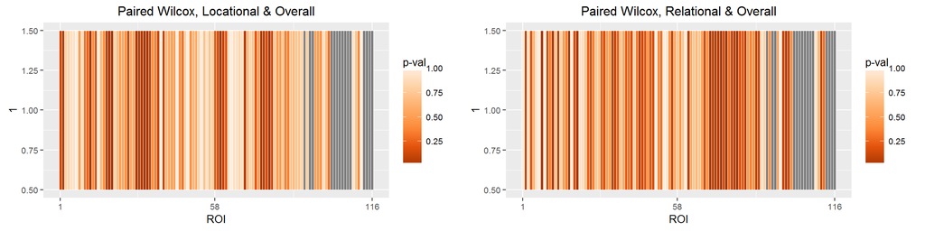

### tGMM on Real Data

```r
  tg_results <- sapply(names(ts), function(sub) tGMM(ts[[sub]],
                                                     means=wwcon_results[[sub]]$means,
                                                     covs=wwcon_results[[sub]]$covs,
                                                     pi_vec = pi_vecs[[sub]]),
                                USE.NAMES=TRUE, simplify=FALSE)
  tgmm_cov <- list()
  tgmm_mean <- list()

  for (i in 1:length(cond_key)) {
    tgmm_cov[[cond_key[i]]] <- list()
    tgmm_mean[[cond_key[i]]] <- list()

    for (id in names(tg_results)) {
      tgmm_cov[[cond_key[i]]][[id]] <- tg_results[[id]]$covs[,,i]
      tgmm_mean[[cond_key[i]]][[id]] <- tg_results[[id]]$means[,i]
    }
  }

  tgmm_mean_wilcox <- wilcox_test_mean(tgmm_mean, subs, runs)

  tgmm_cov_wilcox <- wilcox_test_cov(tgmm_cov, subs, runs)

  tgmm_wilcox_plot_cov <- plot_cov_wilcox(tgmm_cov_wilcox, textsize=10)

  tgmm_wilcox_plot_mean <- plot_mean_wilcox(tgmm_mean_wilcox, textsize=10)
```

We then visualize the wilcoxon plots together to get a better estimate of a comparison of the two algorithms:

#### Relational and Locational

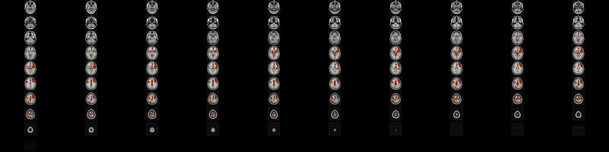

```r
  # atlas is a oro.nifti image
  plot_brain_overlay <- function(atlas, reference, values) {
    require(RColorBrewer)
    ov <- atlas
    # sort the rois so that they go low to small, which is what pipeline outputs
    roimap <- sort(unique(array(atlas@.Data)))
    roimap <- roimap[2:length(roimap)]  # ignore 0 valued roi (no region)
    for (roi in 1:length(values)) {
      if (is.nan(values[roi])) {
        ov@.Data[round(atlas@.Data) == roi] = 0
      } else {
        ov@.Data[round(atlas@.Data) == roi] = 1 - values[roi]
      }
    }
    overlay(reference, ifelse(ov > .9, ov, NA), zlim.y=c(0, 1),
            col.y=brewer.pal(n = 8, name = "Oranges"))
  }

  plot_brain_overlay(atlas, reference, wwcon_mean_wilcox$overall[[1]])
```

#### Relational and Overall

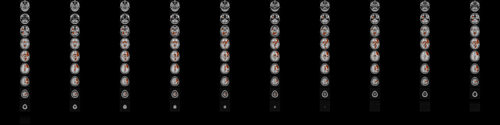

```r
  plot_brain_overlay(atlas, reference, wwcon_mean_wilcox$overall[[2]])
```

#### Locational and Overall

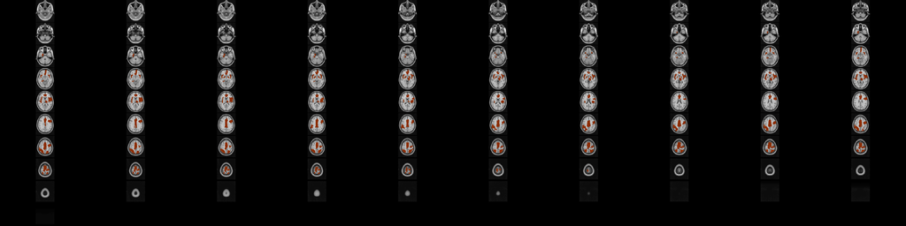

```r
  plot_brain_overlay(atlas, reference, wwcon_mean_wilcox$overall[[3]])
```

```r
  plot_brain_overlay(atlas, reference, tgmm_mean_wilcox$overall[[1]])
```

[output not shown]

#### Relational and Overall

```r
  plot_brain_overlay(atlas, reference, tgmm_mean_wilcox$overall[[2]])
```

[output not shown]

#### Locational and Overall

```r
  plot_brain_overlay(atlas, reference, tgmm_mean_wilcox$overall[[3]])
```

[output not shown]

#### Maximized Covariances

Windowing Method

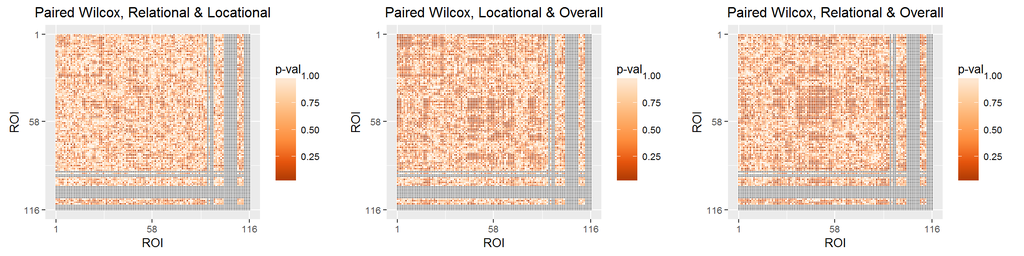